# Probability and Statistics for Data Science

https://uodsci.github.io/dsci345

```python
import matplotlib
import matplotlib.pyplot as plt
matplotlib.rcParams['figure.figsize'] = (15, 8)
import numpy as np
import pandas as pd
```

This is here so we can use `\P` and `\E` in LaTeX below. $$\renewcommand{\P}{\mathbb{P}} \newcommand{\E}{\mathbb{E}}$$

# Uncertainty: (how to) deal with it

When we're doing data science, we

- look at data
- make predictions about future values
- infer aspects of the underlying process

Fundamental to all stages are *randomness* and *uncertainty*.

*For instance:*

Computing **a statistic** gives you a number that describes a data set.

**Doing statistics** helps you understand how reliable that description is and how well it applies to the wider world.

We understand uncertainty, conceptually and quantitatively, with **randomness**,

i.e., through *probability*.

## Goals of this class

- Become familiar with different types of probability models.
- Calculate properties of probability models.
- Construct and simulate from realistic models of data generation.
- Be able to test estimation and prediction methods with simulation.
- Gain familiarity with fundamental statistical concepts.

We'll spend a lot of time on *probability models*, for applications from classical statistics to machine learning.

Course mechanics: https://uodsci.github.io/dsci345

# Getting random

**Today:** *Probability and expectation, conditional probabilities, and random variables.*

First: let's get some [(pseudo-)randomness](https://numpy.org/doc/stable/reference/random/generator.html).

```python
rng = np.random.default_rng()
help(rng.random)
```

```
Help on method random in module numpy.random._generator:

random(size=None, dtype=<class 'numpy.float64'>, out=None) method of numpy.random._generator.Generator instance
    random(size=None, dtype=np.float64, out=None)

    Return random floats in the half-open interval [0.0, 1.0).

    Results are from the "continuous uniform" distribution over the
    stated interval.  To sample :math:`Unif[a, b), b > a` use `uniform`
    or multiply the output of `random` by ``(b - a)`` and add ``a``::

        (b - a) * random() + a

    Parameters
    ----------
    size : int or tuple of ints, optional
        Output shape.  If the given shape is, e.g., ``(m, n, k)``, then
        ``m * n * k`` samples are drawn.  Default is None, in which case a
        single value is returned.
    dtype : dtype, optional
        Desired dtype of the result, only `float64` and `float32` are supported.
        Byteorder must be native. The default value is np.float64.
    out : ndarray, optional
        Alternative output array in which to place the result. If size is not None,
        it must have the same shape as the provided size and must match the type of
        the output values.

    Returns
    -------
    out : float or ndarray of floats
        Array of random floats of shape `size` (unless ``size=None``, in which
        case a single float is returned).

    See Also
    --------
    uniform : Draw samples from the parameterized uniform distribution.

    Examples
    --------
    >>> rng = np.random.default_rng()
    >>> rng.random()
    0.47108547995356098 # random
    >>> type(rng.random())
    <class 'float'>
    >>> rng.random((5,))
    array([ 0.30220482,  0.86820401,  0.1654503 ,  0.11659149,  0.54323428]) # random

    Three-by-two array of random numbers from [-5, 0):

    >>> 5 * rng.random((3, 2)) - 5
    array([[-3.99149989, -0.52338984], # random
           [-2.99091858, -0.79479508],
           [-1.23204345, -1.75224494]])
```

We can look at some typical values:

```python
x = rng.random(size=1000)
print(x[:10])
```

```
[0.18683951 0.05266438 0.93529344 0.14309685 0.97782596 0.3814745
 0.89411    0.75524575 0.30797462 0.79561744]
```

or the largest and smallest values:

```python
print(np.sort(x)[:10])
print(np.sort(x)[-10:])
```

```
[9.76354316e-05 1.44588635e-03 1.90273045e-03 4.36438874e-03
 5.62407159e-03 5.76830880e-03 6.11560716e-03 6.20551101e-03
 8.01122290e-03 8.34627130e-03]
[0.99054436 0.99123959 0.99137274 0.99184206 0.99505733 0.99543316
 0.99748319 0.9983995  0.99911544 0.99992543]
```

We can also plot the results: (left) the simulated values plotted in sorted order, making a steadily increasing line; (right) a histogram of the simulated values, which is more or less flat.

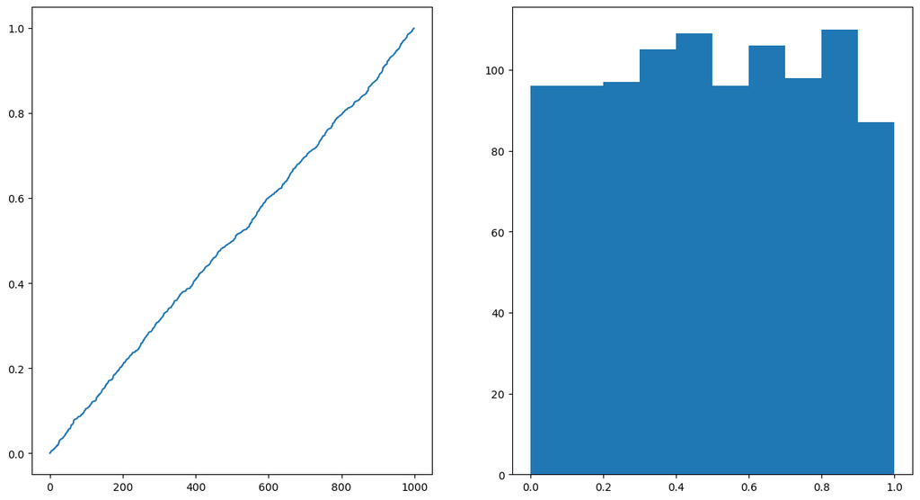

```python
fig, (ax1, ax2) = plt.subplots(1, 2)
ax1.plot(np.sort(x))
ax2.hist(x);
```

**Exercise:** put some other distributions into the code in one of the previous two slides and see what happens.

```python
x = rng.geometric(p=0.5, size=1000)
x[:10]
```

```
array([1, 1, 3, 4, 1, 2, 1, 1, 1, 3])
```

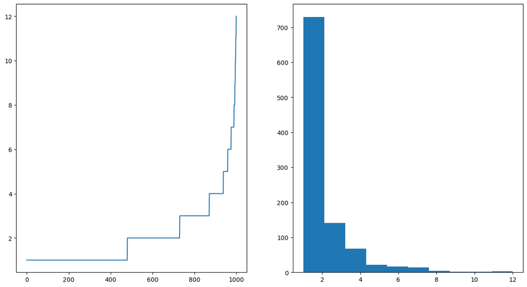

```python
fig, (ax1, ax2) = plt.subplots(1, 2)
ax1.plot(np.sort(x))
ax2.hist(x);
```

```python
x = rng.normal(size=1000)
x[:10]
```

```
array([-1.52349854,  0.33213377, -0.1920977 ,  0.68637205,  0.03317006,
        1.12991139,  0.44031499, -0.16952739, -0.46703779,  0.00187207])
```

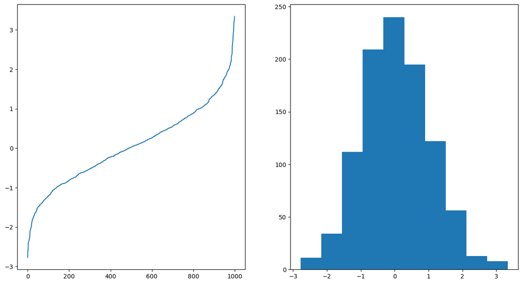

```python
fig, (ax1, ax2) = plt.subplots(1, 2)
ax1.plot(np.sort(x))
ax2.hist(x);
```

# Example: false positives

Suppose that I got a positive result on an HIV test. What’s the chance I am HIV positive? (Here we really mean that “I” am a randomly chosen person from the US population.)

## Background data

A HIV rapid test has 99.4% specificity and 99.8% sensitivity.

Refreshing from [Wikipedia](https://en.wikipedia.org/wiki/Sensitivity_and_specificity), specificity is the “true positive” rate and the sensitivity is the “true negative” rate:

- if you have HIV, the chance that it (wrongly) comes out negative is .006 = 0.6%;
- if you don’t have HIV, the chance that it (wrongly) comes out positive is .002 = .2%.

There are currently around [1.2 million people with HIV in the US](https://www.hiv.gov/hiv-basics/overview/data-and-trends/statistics), out of a total of [333 million](https://www.census.gov/popclock/), giving an overall rate of 0.0036 = 0.36%.

```python
true_pos = .994
true_neg = .998
pop_rate = 1.2 / 333
```

Answer 1: **simulation**

What is the proportion of people who got a positive test result who actually have HIV?

```python
rng.random() < pop_rate
```

```
False
```

```python
# true status
n = 1000000 # number of people
hiv_status = np.array(["+" if x < pop_rate else "-" for x in rng.random(size=n)])
hiv_status[:10]
```

```
array(['-', '-', '-', '-', '-', '-', '-', '-', '-', '-'], dtype='<U1')
```

```python
# simulate tests: go through the people and do the test
# which depends on their true status
test_status = np.array(["" for _ in hiv_status]) # set up an empty list
for k, status in enumerate(hiv_status):
    if status == "+":
        if rng.random() < true_pos:
            test_status[k] = "p"
        else:
            test_status[k] = "n"
    else:
        if rng.random() < true_neg:
            test_status[k] = "n"
        else:
            test_status[k] = "p"

test_status[:10]
```

```
array(['n', 'n', 'n', 'n', 'n', 'n', 'n', 'n', 'n', 'n'], dtype='<U1')
```

```python
pd.crosstab(hiv_status, test_status)
```

| col_0 row_0 | n | p |
| --- | --- | --- |
| + | 21 | 3538 |
| - | 994388 | 2053 |

```python
np.array(hiv_status) == "+"
```

```
array([False, False, False, ..., False, False, False], shape=(1000000,))
```

```python
num_pos_and_test_pos = np.sum(
    np.logical_and(
        hiv_status == "+",
        test_status == "p"
    )
)
num_neg_and_test_pos = np.sum(
    np.logical_and(
        hiv_status == "-",
        test_status == "p"
    )
)
prob_pos_given_test_pos = num_pos_and_test_pos / (num_pos_and_test_pos + num_neg_and_test_pos)
prob_pos_given_test_pos
```

```
np.float64(0.6328027186549812)
```

**Does this answer my question?**

> Suppose that I got a positive result on an HIV test. What’s the chance I am HIV positive?

Not really, since I have more information about how likely it is that I'm HIV+.

*Next answer:* let's use math.

# Probability rules

(i.e., the *axioms of probability*)

## Probability rules

0. *Probabilities are proportions:* $\hspace{2em} 0 \le \P\{A\} \le 1$
1. *Everything:* $\hspace{2em} \P\{ \Omega \} = 1$
2. *Complements:* $\hspace{2em} \P\{ \text{not } A\} = 1 - \P\{A\}$
3. *Disjoint events:* If $\hspace{2em} \P\{A \text{ and } B\} = 0$ then $\hspace{2em} \P\{A \text{ or } B\} = \P\{A\} + \P\{B\}$.
4. *Independence:* $A$ and $B$ are independent iff $\P\{A \text{ and } B\} = \P\{A\} \P\{B\}$.
5. *Conditional probability:* $$\P\{A \;|\; B\} = \frac{\P\{A \text{ and } B\}}{ \P\{B\} }$$

## Bayes' rule

A consequence is that

$$\P\{B \;|\; A\} = \frac{\P\{B\} \P\{A \;|\; B\}}{ \P\{A\} } .$$

(*Example:* HIV test calculation, on the board.)

We want to know the proportion of people who got a positive test result who actually have HIV.

i.e.

- $A$ is that they get a positive test result, and
- $B$ is that they have HIV.

- $\mathbb{P}\{A \text{ and } B\} = \mathbb{P}\{B\} \times \mathbb{P}\{A|B\} = 0.0036 \times .994$
- $\mathbb{P}\{A\} = \mathbb{P}\{A\text{ and }B\} + \mathbb{P}\{A\text{ and not }B\} = 0.0036 \times .994 + (1 - 0.0036) \times (1 - .998)$

```python
num = pop_rate * true_pos
denom = num + (1 - pop_rate) * (1 - true_neg)
num / denom
```

```
0.6425339366515835
```